# Investigating the consequences of increased T cell infiltration on Uveal Melanoma tumor samples

James Swift

2023-01-23

### Prerequisites

```r
library(tidyverse)
library(survival)
library(survminer)
library(ggsurvfit)
library(DESeq2)
library(DT)
library(tinytex)
```

### Data import & tidying

```r
T_cell_genes_conventional <- c("SAMD9", "RTP4", "IFIH1", "DDX60",
                      "IFI27", "ISG20", "PARP14", "PARP12",
                      "IFIT5", "IRF9", "EPSTI1", "OAS1",
                      "IFNG", "CXCL9", "CXCL10", "GZMB",
                      "PRF1", "PMEL", "TYRP1", "TAP1",
                      "TAP2", "PSMB8", "HLA-A", "HLA-B",
                      "HLA-C", "SAMD9", "RTP4", "IFIH1", "DDX60", "IFI27", "ISG20", "PARP14",
                      "PARP12", "IFIT5", "IRF9", "EPSTI1", "OAS1", "IFNG", "CXCL9",
                      "CXCL10", "CD4", "LTB", "IL7R", "KLF4", "IRF8", "BATF3",
                      "CD2", "BTLA", "CLEC9A", "ID2", "CD141", "CD3D", "CD3E",
                      "PTPRC", "PRF1", "PDCD1", "TNFRSF18", "HAVCR2", "CD40", "CD274",
                      "LAG3", "VTCN1", "TNFRSF9", "IL2RB", "IDO1", "TNFRSF4", "CTLA4",
                      "PDCD1LG2", "ICOS", "CD276", "CXCL8", "UBA7", "GBP1", "GBP2",
                      "GBP3", "CD8A")

T_cell_genes_unconventional <- c("TRAV1-1", "TRAV2", "TRAV3", "TRGV9",
                                 "TRDV1", "TRDV2", "TRDV3", "CD1C",
                                 "CD1A", "BTNL2", "BTN3A1","BTN1A1",
                                 "BTN2A2", "BTN3A3", "BTN2A1", "BTN3A2",
                                 "BTNL3", "BTNL8", "BTNL9", "BTN2A3P",
                                 "BTNL10", "BTN1A1P1", "CD1D", "CD1B",
                                 "KLRB1", "CCL3", "CCL4", "PRDM1", "TRDC")

T_cell_genes_all <- c(T_cell_genes_conventional, T_cell_genes_unconventional)
```

```r
clinical_df <- readRDS("/srv/shiny-server/tcga-2022-dev/data/output/clinical.rds") #for survival

meta_samp <- read_tsv("/srv/shiny-server/tcga-2022-dev/data/output/merged_samp_sheet.tsv") %>%
  arrange("File Name") %>%
  filter(!duplicated(`Sample ID`))

data <- readRDS("/srv/shiny-server/tcga-2022-dev/data/output/log2fpkm_uq.rds")

significant_expression <- readRDS(file = "~/Documents/exploratory_analysis/data/output/expression_mean.rds") %>%
  filter(a >= 1) %>% #filters out noise
  pull(GeneID)

pval_data <- readRDS(file = "~/Documents/exploratory_analysis/data/output/survival-pval.RDS") %>%
  as_tibble() %>%
  filter(gene %in% significant_expression) %>%
  select(pval, gene, project) %>%
  mutate(pval = as.double(pval))

hazard_data <- readRDS(file = "~/Documents/exploratory_analysis/data/output/survival-hazard.RDS") %>%
  as_tibble() %>%
  filter(gene %in% significant_expression) %>%
  rename("value" = "hazard")

pval_hazard_df <- left_join(pval_data, hazard_data) %>%
  select(gene, project, pval, hazard) %>%
  arrange(-hazard, pval)
```

### Increased T cell infiltration has a negative impact on overall survival in some pathologies

#### Red line indicates a significance (p-value) of 0.01

UVM and LGG show a negative correlation between overall survival and T cell infiltration. KIRC and THYM show a similar pattern, but have considerably fewer data points.

Both UVM and LGG pathologies occur in immunopriviledged areas.

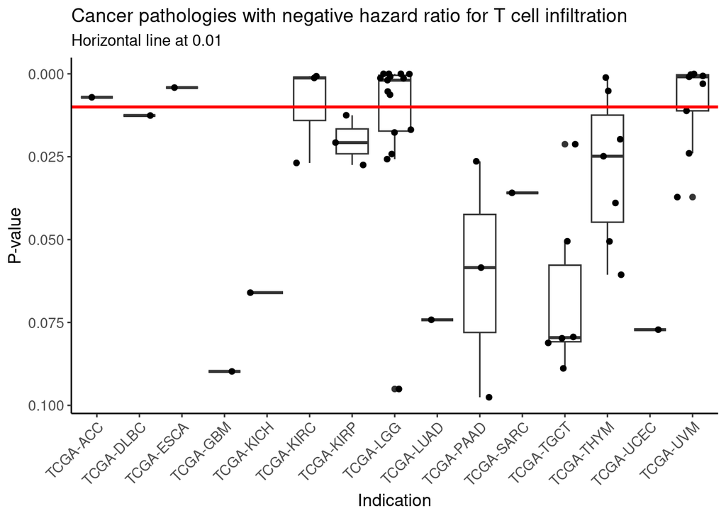

```r
plot_by_indication <- pval_hazard_df %>%
  filter(gene %in% T_cell_genes_all) %>%
  filter(pval <= 0.1) %>%
  filter(hazard < 1) %>%
  ggplot(aes(
    x = project,
    y = pval
  )) +
  geom_boxplot() +
  scale_y_reverse() +
  geom_jitter() +
  scale_fill_manual(values=c("red","green","blue")) +
  guides(colour = guide_legend(nrow = 1)) +
  labs(
    x = "Indication",
    y = "P-value",
    title = "Cancer pathologies with negative hazard ratio for T cell infiltration",
    subtitle = "Horizontal line at 0.01"
  ) +
  custom_theme +
  geom_hline(yintercept = 0.01, linewidth = 1, color = "red")
```

### T cell gene expression grouped by hazard ratio

```r
positive_hazard_df <- pval_hazard_df %>%
  filter(gene %in% T_cell_genes_all) %>%
  arrange(-hazard, pval) %>%
  filter(project %in% c("TCGA-UVM", "TCGA-LGG")) %>%
  filter(pval <= 0.05)

positive_hazard_df <- positive_hazard_df %>% mutate(facet = if_else(positive_hazard_df$hazard > 3, "High positive hazard (HR > 3)", "Low positive hazard (3 > HR >= 2)"))
```

```r
positive_hazard <- positive_hazard_df %>%
  ggplot(aes(
    x = project,
    y = pval,
    color = gene,
  )) +
  facet_grid(~facet) +
  scale_y_reverse() +
  geom_jitter() +
  geom_hline(yintercept = 0.01, color = "red", linewidth = 1) +
  labs(
    x = "Indication",
    y = "P-value",
  ) +
  custom_theme +
  theme(legend.position = "none")
```

```r
negative_hazard_df <- pval_hazard_df %>%
  filter(gene %in% T_cell_genes_all) %>%
  arrange(hazard, pval) %>%
  filter(project %in% c("TCGA-UVM", "TCGA-LGG")) %>%
  filter(pval <= 0.05)

negative_hazard_df <- negative_hazard_df %>% mutate(facet = if_else(negative_hazard_df$hazard < 0.333, "High negative hazard (HR < 0.333)", "Low negative hazard (0.333 < HR <= 1)"))
```

```r
negative_hazard <- negative_hazard_df %>%
  ggplot(aes(
    x = project,
    y = pval,
    color = gene,
  )) +
  facet_grid(~facet) +
  scale_y_reverse() +
  geom_jitter() +
  geom_hline(yintercept = 0.01, color = "red", linewidth = 1) +
  labs(
    x = "Indication",
    y = "P-value",
  ) +
  custom_theme +
  theme(legend.position = "none")
```

#### UVM shows a higher negative hazard ratio for more T cell genes than LGG

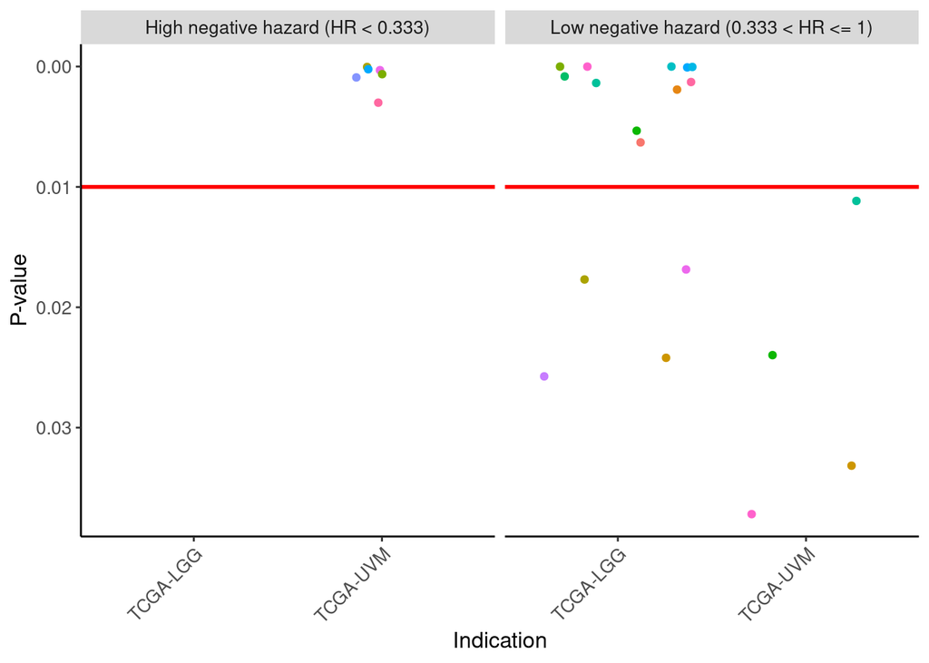

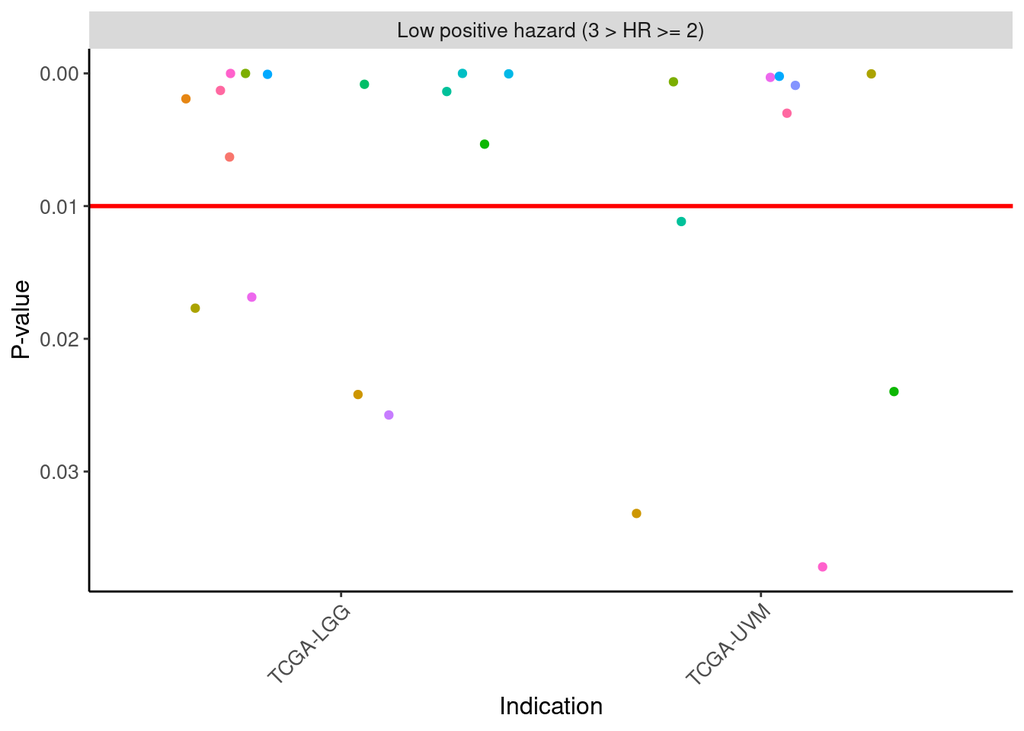

### T cell genes most strongly correlated with OS

CD8A paradoxically shows to be highly negative correlated with overall survival. Meanwhile, CD40 is correlated positively with overall survival.

```r
gene_hazard_pval_table_uvm <- pval_hazard_df %>%
  filter(gene %in% T_cell_genes_all) %>%
  arrange(hazard, pval) %>%
  filter(project == "TCGA-UVM") %>%
  select(!project) %>%
  filter(pval <= 0.05) %>%
  mutate("pval" = format(round(pval, 5), nsmall = 5)) %>%
  mutate("hazard" = format(round(hazard, 5), nsmall = 5)) %>%
  datatable()

gene_hazard_pval_table_uvm
```

|  | gene | pval | hazard |
| --- | --- | --- | --- |
| 1 | CD8A | 0.00004 | 0.14945 |
| 2 | IL2RB | 0.00022 | 0.17136 |
| 3 | LAG3 | 0.00030 | 0.19712 |
| 4 | GBP1 | 0.00063 | 0.22037 |
| 5 | IRF8 | 0.00091 | 0.23539 |
| 6 | PTPRC | 0.00300 | 0.26640 |
| 7 | HAVCR2 | 0.01116 | 0.33927 |
| 8 | GBP2 | 0.02398 | 0.36850 |
| 9 | OAS1 | 0.03719 | 0.40893 |
| 10 | CD40 | 0.03316 | 2.57007 |

```r
data <- readRDS("/srv/shiny-server/tcga-2022-dev/data/output/unstranded.rds") # obviosuly this isn't the right data

meta_samp <- read_tsv("/srv/shiny-server/tcga-2022-dev/data/output/merged_samp_sheet.tsv") %>%
  arrange("File Name") %>%
  filter(!duplicated(`Sample ID`)) %>%
  filter(`Project ID` == "TCGA-UVM")

clinical_df <- readRDS("/srv/shiny-server/tcga-2022-dev/data/output/clinical.rds") %>%
  filter(submitter_id %in% meta_samp$`Case ID`) %>%
  filter(!duplicated(submitter_id)) %>%
  filter(!is.na(time)) %>%
  filter(time > -1) %>%
  rename("vital_status" = "survival") %>%
  mutate(survival = ifelse(survival == 1, "dead", "alive")) %>%
  rename("submitter_id" = "Case ID") %>%
  select(`Case ID`, survival)

meta_samp <- meta_samp %>%
  filter(`Case ID` %in% clinical_df$`Case ID`) %>%
  left_join(clinical_df, by = "Case ID")

count_data <- data %>%
  select(colnames(data)[1],
         meta_samp$`Sample ID`) %>%
  filter(!duplicated(GeneID)) %>% # why were these even duplicated in the first place, and does this mean anything for tcga-app
  column_to_rownames(var = "GeneID") %>%
  as.matrix()
```

```r
dds <- DESeqDataSetFromMatrix(countData = count_data,
                              colData = meta_samp,
                              design = ~ survival)

dds <- DESeq(dds, betaPrior = FALSE, parallel = T)

res <- lfcShrink(dds, contrast = c("survival", "dead", "alive"), type = "normal")

deseq2_df <- res %>%
  as.data.frame() %>%
  rownames_to_column(var = "GeneID")
```

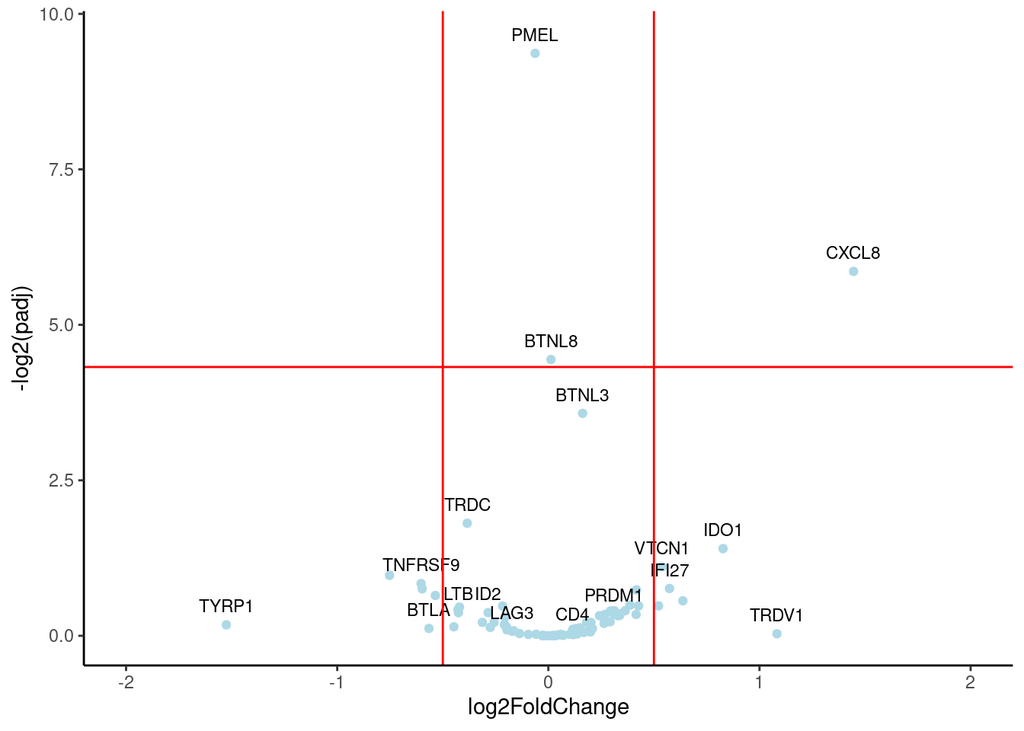

### Function of genes correlated with OS

#### CD40

- Member of the TNF-receptor superfamily
- Receptor on antigen-presenting cells
- T cell-dependent Ig class switching

#### CD8A

- Classic T cell stuff

#### IL2Rb

- Binds IL2
- Required for Treg activation
- Required for Th2 activation

#### LAG3

- Associates with CD3-TCR in immunological synapse and directly inhibits T cell activation, other mechanisms

#### GBP/2

- GTPase, expression is induced by interferon

- Stimulates immune response against tumour cells
- Supresses tumour cell growth

#### PTPRC

- Regulation of T cell antigen receptor signalling

#### HAVCR2

- Th1 cell surface protein that regulates macrophage activation
- Promotes a tolerogenic immune state

#### OAS1

- Activates RNase L leading to degradation of cellular RNA

### Why does increased T cell infiltration in Uveal Melanoma cases cause decreased overall survival?

One the theory suggests that this effect is not a direct result of the T cell infiltration, but rather as a result of the step that lead to increased T cell infiltration - i.e. cytokine release. I t has been found that tissues in uveal melanoma express significant levels of IL-2 receptors (which I believe is usually just limiting to immune cells, but I need to check this). IL-2 has many functions, but importantly it leads to the activation (and thus proliferation) of certain subsets of T cells (Th1 and Tregs), which in turn may lead help in the activation of CD8 T cells, which explains the high expression levels found in UVM primary tumour samples. Crucially, IL-2 leads to proliferation of immune cells. Therefore, since tumour cells in uveal melanoma also expression IL-2 receptors, it has been hypothesized that increased IL-2 secretion locally within the tumour microenvironment, paradoxically leads to the proliferation of the tumour cells, rather than their destruction.

### All genes correlated with OS

```r
gene_hazard_pval_table_all <- pval_hazard_df %>%
  filter(project == "TCGA-UVM") %>%
  arrange(hazard, pval) %>%
  filter(pval <= 0.05) %>%
  mutate("pval" = format(round(pval, 5), nsmall = 5)) %>%
  mutate("hazard" = format(round(hazard, 5), nsmall = 5)) %>%
  datatable()

gene_hazard_pval_table_all
```

|  | gene | project | pval | hazard |
| --- | --- | --- | --- | --- |
| 1 | ELOC | TCGA-UVM | 0.00000 | 0.05230 |
| 2 | SOCS2 | TCGA-UVM | 0.00000 | 0.06519 |
| 3 | EIF4E2 | TCGA-UVM | 0.00000 | 0.06673 |
| 4 | PSMA7 | TCGA-UVM | 0.00002 | 0.08217 |
| 5 | CD96 | TCGA-UVM | 0.00001 | 0.09126 |
| 6 | ASB9 | TCGA-UVM | 0.00001 | 0.09976 |
| 7 | CTSC | TCGA-UVM | 0.00000 | 0.10089 |
| 8 | VAV2 | TCGA-UVM | 0.00001 | 0.10379 |
| 9 | PLPP5 | TCGA-UVM | 0.00002 | 0.10634 |
| 10 | XRCC5 | TCGA-UVM | 0.00003 | 0.11254 |

[output cut: 270 more lines]

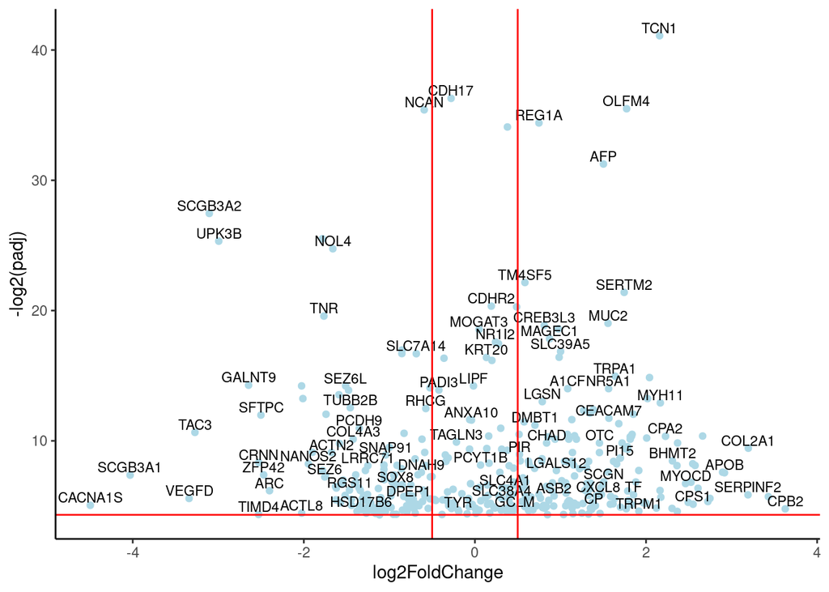